# Choosing an atlas

Martin Westgate & Dax Kellie

2024-11-05

The GBIF network consists of a series of a series of ‘node’ organisations who collate biodiversity data from their own countries, with GBIF acting as an umbrella organisation to store data from all nodes. Several nodes have their own APIs, often built from the ‘living atlas’ codebase developed by the ALA. `galah` enables you to download data either from GBIF (see also `rgbif`) or from one of 9 GBIF nodes:

| Region | Organisation | Number of Records | Number of supported APIs |
| --- | --- | --- | --- |
| Global | Global Biodiversity Information Facility | 2457308452 | 11 |
| United Kingdom | National Biodiversity Network | 298318126 | 19 |
| Sweden | Swedish Biodiversity Data Infrastructure | 153805087 | 23 |
| France | Portail français d'accès aux données d'observation sur les espèces | 153402324 | 14 |
| Australia | Atlas of Living Australia | 146132636 | 24 |
| Spain | GBIF Spain | 59673279 | 24 |
| Brazil | Sistemas de Informações sobre a Biodiversidade Brasileira | 36509671 | 18 |
| Portugal | GBIF Portugal | 16043865 | 15 |
| Austria | Biodiversitäts-Atlas Österreich | 9173597 | 19 |
| Guatemala | Sistema Nacional de Información sobre Diversidad Biológica de Guatemala | 4225159 | 16 |

Choosing which node to query is not entirely straightforward. Broadly speaking, GBIF is always an easy answer, because it has information from many countries. If you only want data from a single country, however, the nodes may offer some advantages. Namely, GBIF nodes may support locally-specific:

- **fields** that can be used for more efficient filtering
- **taxonomies** that reflect changes not yet adopted by the GBIF taxonomic backbone
- **services** that are not offered by GBIF such as error checking or large downloads

Ultimately, `galah` aims to provide *access* to as many GBIF nodes as possible; it’s up to you which node organisation’s data are suitable for your needs! We currently support the following functions and atlases:

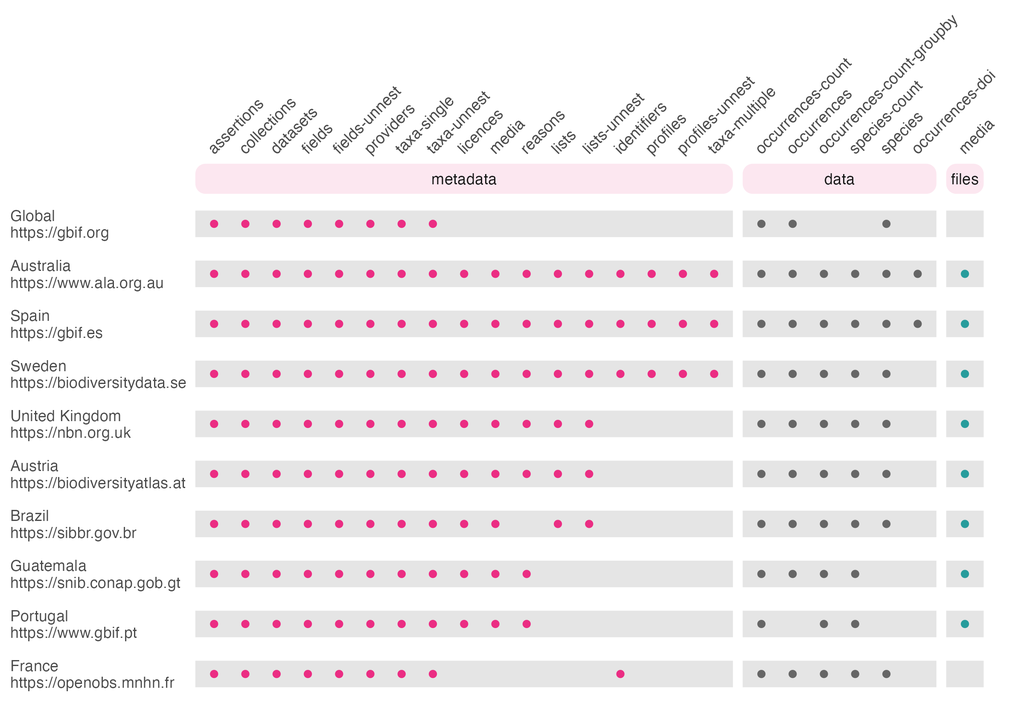